# CSC 453

Operating Systems

# This class

## Who am I?

- https://pschmitt.net
- Academics
  - PhD at UCSB
  - Researcher at UC Berkeley (ICSI)
  - Postdoc then research faculty at Princeton
  - Some other stops… USC, Stanford, UH
- Privacy startup co-founder & CEO, measurement startup COO
- Main focuses
  - Integrating privacy and security into systems that we all use
  - ML for network management
  - Connectivity / privacy in challenging environments

## This class

- Too much to cover in one term: survey of important topics
- Course Canvas: https://canvas.calpoly.edu/courses/178871
- Syllabus: https://schmittpaul.github.io/CSC453S26/syllabus.pdf
- Waitlists…
- What OSes do you all run?

## Who are you?

- Name / Major / Year
- Where do you identify as your hometown?

## How to succeed in this class

- Turn things in on time
- Attend class
  - … on time. Lectures will start at 10 after the hour
- Ask questions
  - I’m very flexible about how much we cover this term
  - I would rather teach less and have everyone understand it
  - Our back-and-forth during class is the one of the few indicators I have of how much you are absorbing
- Talk to me if you are struggling

## What are we doing here?

- How many of you have participated in OS development?
- How many of you regularly program in languages that use operating system abstractions directly?
- And C is a decreasingly popular language!
- So why study operating systems? Why is this class even offered? Why is it required?

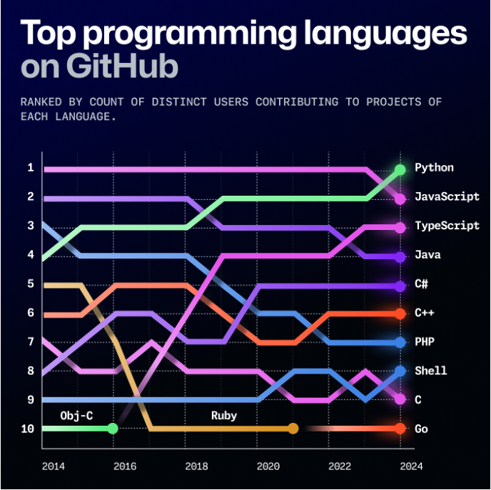

## Why take this class

- You are required to do so in order to graduate
- Reality: this is how computers really work, and as a computer scientist or engineer you should know how computers really work
- Ubiquity: operating systems are everywhere and you are likely to eventually encounter them or their limitations
- Beauty: operating systems are examples of mature solutions to difficult design and engineering problems. Studying them will improve your ability to design and implement abstractions

## Course progression

- Introduction to operating system abstractions and structures
- Abstracting and multiplexing:
  - CPU: interrupts, context, threads, processes, processor scheduling, thread synchronization, deadlocks
  - Memory: memory layout, address translation, paging and segmentation, address spaces, translation caching, page fault handling, page eviction, swapping
  - File systems and storage: disk scheduling, on-disk layout, files, buffer cache, crash and recovery
  - Security (time permitting)

# Background

## Questions to consider

- What is an operating system?
- What do they do?
- How did OSes evolve?
- How do the requirements differ for different OSes?

## What is an operating system?

- Operating System:
  - A computer program that
  - multiplexes hardware resources and
  - implements useful abstractions.
- The OS is just another computer program. Has the highest privilege. The core of the OS consists of the kernel
- Multiplexing allows multiple people or programs to use the same set of hardware resources - processors, memory, disks, network connection - safely and efficiently.
- Abstractions simplify the usage of hardware resources by organizing information or implementing new capabilities.

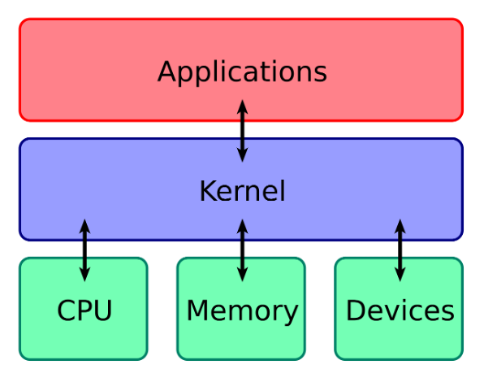

## OS history - how did we get here?

- Started out as libraries to provide common functionality across programs
  - See any issues with this approach?
- Later, evolved from procedure call to system call
  - What’s the difference?
- Evolved from running a single program to multiple processes concurrently
  - New issues to solve?

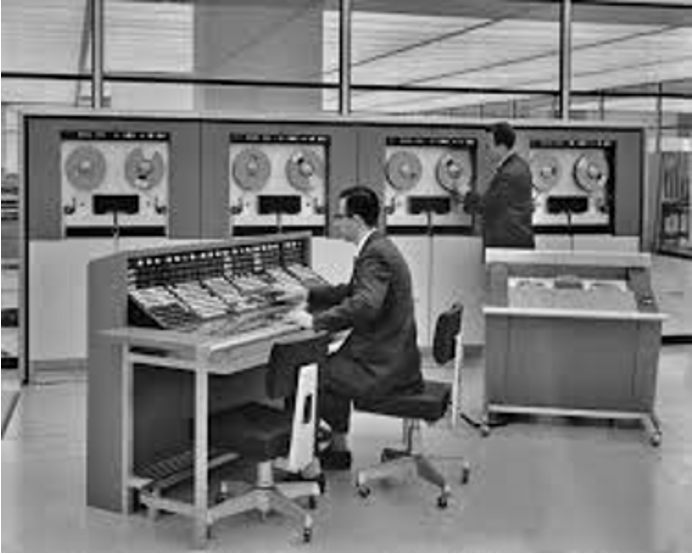

## Types of operating systems

- Desktop
- Time share/Mainframe
- Mobile
- Web
- Real-time
- Embedded
- Virtual Machines

## Tl;dr

OSes continue to evolve as environments (i.e., constraints) change

What isn’t clear?

Comments? Thoughts?

# OS abstractions

## Questions to consider

- What are the main abstractions OSes provide?
- What are the abstraction challenges?

## Abstractions

- Abstractions *simplify application design* by:
  - hiding undesirable properties,
  - adding new capabilities, and
  - organizing information
- Abstractions provide an interface to application programmers that separates policy—what the interface commits to accomplishing—from mechanism—how the interface is implemented.

## What are the abstractions?

- CPUs
  - Processes, threads
- Memory
  - Address space
- Disk
  - Files

## Example OS abstraction: file systems

- What undesirable properties do file systems hide?
  - Disks are slow!
  - Chunks of storage are actually distributed all over the disk
  - Disk storage may fail!
- What new capabilities do files add?
  - Growth and shrinking
  - Organization into directories, searchability
- What information do files help organize?
  - Ownership and permissions
  - Access time, modification time, type, etc.

## Abstraction tradeoffs - discussion

- Identify undesirable properties hidden by, new capabilities added, and info organization provided with these abstractions:
  - Process / threads
  - Address space

## Abstraction pros / cons

- Advantages of OS providing abstractions?
  - Allow applications to reuse common facilities
  - Make different devices look the same
  - Provide higher-level or more useful functionality
- Challenges?
  - What are the correct abstractions?
  - How much should be exposed?